# IS6400-2223B-CityU-IS-Assignment2_57584800_WANG_Guanzhang

IS6400 22/23 Semester B

- Assignment 2 （Week 2 to Week 4）

Cenying (Tracy) Yang (cenying.yang@cityu.edu.hk)

Department of Information Systems

City University of Hong Kong

```python
import numpy as np
import pandas as pd
```

```python
from sklearn import metrics, linear_model, model_selection
```

```python
from statsmodels.tsa.exponential_smoothing.ets import ETSModel
from statsmodels.tsa.stattools import kpss
```

# Prediction via Regression [65%]

## Concepts [25%]

- In a linear regression, what is the approach to get optimal coefficients? Briefly describe how it works.**[5%]**

**ANS**:

> For this purpose, we use the "Least square" to get the optimal coefficients. When we applied this approach, we tried to minimize the square of the error and find the best-fitting line.
- What is major challenge in training a good model? How would you describe an ideal model? **[10%]**

**ANS**:

> Balancing the bias and the variance is the major problem for building a good model. Unbalance of them will cause two problems: **underfitting** happens when a model cannot capture the dataset's underlying pattern. These models usually have high bias and low variance. **overfitting** happens when our model captures the noise along with the underlying pattern in the dataset.

> Personally, I believe that an ideal model will get a good balance between bias and variance. Both will be low to some extent, and the model will get the best performance.
- We can add ridge penalty or Lasso penalty to address the challenge. What are the major differences between ridge penalty and Lasso penalty? **[10%]**

**ANS**:

> In ridge penalty, we are trying to "shrink". We keep all features in the regression model, the coefficients may be approached to 0, but it won't be an actual 0.

> In the LASSO penalty, we will work on "feature selection". Some coefficients will be defined as "0".

## Hands-on Applications [40%]

Read the dataset `Hitters.csv` using `pd.read_csv` to conduct the following analysis. It contains data on Major League Baseball from 1986 and 1987 seasons. It contains 20 variables. You can find a description of 20 variables here (https://www.kaggle.com/datasets/mathchi/hitters-baseball-data?resource=download). In this problem, you need to build a prediction model to predict players’ salary based on their performance statistics.

- HINT: make sure you save `Hitters.csv` in the current working directory.

```python
hitters = pd.read_csv('Hitters.csv')
hitters.head()
```

|  | AtBat | Hits | HmRun | Runs | RBI | Walks | Years | CAtBat | CHits | CHmRun | CRuns | CRBI | CWalks | League | Division | PutOuts | Assists | Errors | Salary | NewLeague |
| --- | --- | --- | --- | --- | --- | --- | --- | --- | --- | --- | --- | --- | --- | --- | --- | --- | --- | --- | --- | --- |
| 0 | 315 | 81 | 7 | 24 | 38 | 39 | 14 | 3449 | 835 | 69 | 321 | 414 | 375 | N | W | 632 | 43 | 10 | 475.0 | N |
| 1 | 479 | 130 | 18 | 66 | 72 | 76 | 3 | 1624 | 457 | 63 | 224 | 266 | 263 | A | W | 880 | 82 | 14 | 480.0 | A |
| 2 | 496 | 141 | 20 | 65 | 78 | 37 | 11 | 5628 | 1575 | 225 | 828 | 838 | 354 | N | E | 200 | 11 | 3 | 500.0 | N |
| 3 | 321 | 87 | 10 | 39 | 42 | 30 | 2 | 396 | 101 | 12 | 48 | 46 | 33 | N | E | 805 | 40 | 4 | 91.5 | N |
| 4 | 594 | 169 | 4 | 74 | 51 | 35 | 11 | 4408 | 1133 | 19 | 501 | 336 | 194 | A | W | 282 | 421 | 25 | 750.0 | A |

Because Salary is highly right skewed. Let's take log transformation of the variable.

```python
hitters['log_salary'] = np.log(hitters['Salary'])
```

Now, let's get X and y respectively.

```python
X = hitters[['AtBat','Hits', 'HmRun', 'Runs','RBI', 'Walks', 'Years', 'CAtBat', 'CHits', 'CHmRun',
           'CRuns', 'CRBI', 'CWalks', 'PutOuts','Assists','Errors']].values
y = hitters['log_salary'].values
```

1. Randoml spilt the dataset into 80% training data and 20% testing data. You need to print the number of data points in both the training and testing sets. **[5%]**
   - HINT: Please set the random_state = 42 to make results reproducible. If you do not do this, you will get penalized.

```python
X_train, X_test, y_train,y_test = model_selection.train_test_split(X,y,test_size=0.2,random_state=42)
```

1. Train the regression model and do testing:
   - Use a multiple linear regression to predict the target variable `y` **[4%]**
     - HINT: use the `.predict` function after `.fit`
   - Print out the training error and testing error (mean squared error). **[4%]**
     - HINT: use [metrics.mean_squared_errors](https://scikit-learn.org/stable/modules/generated/sklearn.metrics.mean_squared_error.html)

```python
lm_fit = linear_model.LinearRegression().fit(X_train,y_train)
train_predict = lm_fit.predict(X_train)
test_predict= lm_fit.predict(X_test)
print("Train Error:", metrics.mean_absolute_error(y_true = y_train,y_pred=train_predict))
print("Test Error" , metrics.mean_squared_error(y_true= y_test, y_pred=test_predict))
```

```
Train Error: 0.4915505648267067
Test Error 0.38463034791600115
```

1. Let's now do the following modelling:
   1. Apply both ridge regression and Lasso regression models using default alpha = 1.**[8%]**
      - print out training error and testing error (mean squared error)
   2. Use 5-fold cross validation to pick the optimal alpha in both ridge and Lasso. Run ridge and Lasso again using the optimal alpha. **[14%]**
      - Use `RidgeCV` and `LassoCV` to apply cross validation. Use the set of alpha values [0.1, 0.5, 1.0, 5, 10.0].
      - print out the best alpha for ridge and Lasso respectively.
      - print out training error and testing error (mean squared error) for ridge and Lasso respectively.

```python
lm_ridge = linear_model.Ridge()
lm_ridge_fit = lm_ridge.fit(X_train, y_train)
ridge_train_pred = lm_ridge_fit.predict(X_train)
ridge_test_pred = lm_ridge_fit.predict(X_test)
print("Train Error in Ridge regression: ", metrics.mean_squared_error(y_true = y_train, y_pred = ridge_train_pred))
print("Test Error in Ridge regression: ", metrics.mean_squared_error(y_true = y_test, y_pred = ridge_test_pred))
print("----------------------------------------")
lm_lasso = linear_model.Lasso()
lm_lasso_fit = lm_lasso.fit(X_train, y_train)
lasso_train_pred = lm_lasso_fit.predict(X_train)
lasso_test_pred = lm_lasso_fit.predict(X_test)
print("Train Error in LASSO regression: ", metrics.mean_squared_error(y_true = y_train, y_pred = lasso_train_pred))
print("Test Error in LASSO regeression", metrics.mean_squared_error(y_true = y_test, y_pred = lasso_test_pred))
```

```
Train Error in Ridge regression:  0.3597251158768388
Test Error in Ridge regression:  0.38457837632798325
----------------------------------------
Train Error in LASSO regression:  0.3914094465469061
Test Error in LASSO regeression 0.4083155076890916
```

```python
# prepare for the RidgeCV
lm_ridgeCV = linear_model.RidgeCV(alphas = [0.1, 0.5, 1.0, 5, 10.0], cv = 5)
# fit
lm_ridgeCV_fit = lm_ridgeCV.fit(X_train, y_train)
# get the Alpha
print("Alpha of RidgeCV",lm_ridgeCV_fit.alpha_)
# predict
ridgeCV_train_pred = lm_ridgeCV_fit.predict(X_train)
ridgeCV_test_pred = lm_ridgeCV_fit.predict(X_test)
# present the result
print("Train Error in RidgeCV: ", metrics.mean_squared_error(y_true = y_train, y_pred = ridgeCV_train_pred))
print("Test Error in RidgeCV: ", metrics.mean_squared_error(y_true = y_test, y_pred = ridgeCV_test_pred))
print("----------------------------------------")
#prepare for the LASSOCV
lm_lassoCV = linear_model.LassoCV(alphas = [0.1, 0.5, 1.0, 5, 10.0], cv = 5)
# fit
lm_lassoCV_fit = lm_lassoCV.fit(X_train, y_train)
# get the alpha
print("Alpha of LASSOCV",lm_lassoCV_fit.alpha_)
# predict
lassoCV_train_pred = lm_lassoCV_fit.predict(X_train)
lassoCV_test_pred = lm_lassoCV_fit.predict(X_test)
# present the result
print("Train Error in LASSOCV: ", metrics.mean_squared_error(y_true = y_train, y_pred = lassoCV_train_pred))
print("Test Error in LASSOCV", metrics.mean_squared_error(y_true = y_test, y_pred = lassoCV_test_pred))
```

```
Alpha of RidgeCV 0.1
Train Error in RidgeCV:  0.35972506868058807
Test Error in RidgeCV:  0.3846251344543006
----------------------------------------
Alpha of LASSOCV 5.0
Train Error in LASSOCV:  0.41306939269320375
Test Error in LASSOCV 0.4300804506353156
```

- Based on your results, which model is the best and why? **[5%]**

**ANS**:

> Because our target is build up a predict model, therefore we need to focus on who has the lowest error in the test.

> Base on the result, We should choose Ridge with default Alpha

# Time Series Forecasting [35%]

## Concepts [15%]

- What are the three components in a time series dataset? **[5%]**

**ANS**:

> Trendy, Seasonality, Random
- What are the common approaches to data partioning for forecast performance evaluation? Provide two methods **[5%x2]**

**ANS**:

> One-time split: split data based on the given date

> Rolling forward: divide the data into multiple timelines, use a part of them to train, and check the accuracy of the next point. After that, involve this point in the train set, so reciprocate

## Hands-on [20%]

Read the dataset `online_retail.csv` using `pd.read_csv` to conduct the following analysis. It contains sales volume data from an online retailer.

- HINT: make sure you save `Hitters.csv` in the current working directory.

```python
retail = pd.read_csv('online_retail.csv')
retail = retail.loc[retail['Quantity'] > 0] # remove observations where quantity is non positive
retail.head()
```

|  | Quantity | InvoiceDate |
| --- | --- | --- |
| 0 | 6 | 12/1/2010 8:26 |
| 1 | 6 | 12/1/2010 8:26 |
| 2 | 8 | 12/1/2010 8:26 |
| 3 | 6 | 12/1/2010 8:26 |
| 4 | 6 | 12/1/2010 8:26 |

Covert the `InvoiceDate` to `datetime` type. Run the code below. No need to understand it. But if you are interested, you can ask me :)

```python
retail['InvoiceDate'] = retail['InvoiceDate'].apply(lambda x: pd.to_datetime(x, format = '%m/%d/%Y %H:%M')
                            if len(x.split(' ')[0].split('/')[2])==4
                            else pd.to_datetime(x, format = '%m/%d/%y %H:%M'))
retail['date'] = retail['InvoiceDate'].dt.date
retail.head()
```

|  | Quantity | InvoiceDate | date |
| --- | --- | --- | --- |
| 0 | 6 | 2010-12-01 08:26:00 | 2010-12-01 |
| 1 | 6 | 2010-12-01 08:26:00 | 2010-12-01 |
| 2 | 8 | 2010-12-01 08:26:00 | 2010-12-01 |
| 3 | 6 | 2010-12-01 08:26:00 | 2010-12-01 |
| 4 | 6 | 2010-12-01 08:26:00 | 2010-12-01 |

1. Visualize the daily time series data using line plot (x-axis is date and y is sales volume). **[3%]**
   - HINT: use `groupby` and `sum` function to get total daily sales volume. Save the result as `retail_daily` and then apply `plot.line` function.

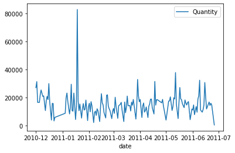

```python
retail_daily = retail.groupby("date")["Quantity"].sum().to_frame()
retail_daily.plot.line()
```

1. Please answer the two questions:
   1. Do you think it is stationary based on the figure above? Why? **[2%]**
   2. Confirm with the KPSS test at a confidence level of 95% (you need to (1) use `statsmodels` and check the p-value of the returned statistics, and (2) briefly describe your conclusion based on the p-value). **[3%]**

**ANS**:

> I think it seems may stationary due to it has not too many vibrate and no apparently trend according to the figure

> The following function will answer the question2

```python
def kpss_test(series):
    statistic, p_value, n_lags, critical_values = kpss(series)
    # Format Output
    print(f'KPSS Statistic: {statistic}')
    print(f'p-value: {p_value}')
    print(f'num lags: {n_lags}')
    print('Critial Values:')
    for key, value in critical_values.items():
        print(f'{key} : {value}')
    print(f'Result: The series is {"not " if p_value < 0.05 else ""}stationary')

kpss_test(retail_daily)
```

```
KPSS Statistic: 0.19028776289943494
p-value: 0.1
num lags: 2
Critial Values:
10% : 0.347
5% : 0.463
2.5% : 0.574
1% : 0.739
Result: The series is stationary
```

1. Split the dataset into train and test sets. The training data should be 90% of the `retail_daily` and the testing data should be 10%. Be aware about the temporal order. You should print the shape of the training and testing sets at the end.**[5%]**

```python
retail_daily_ri = retail_daily.reset_index(drop=False)

Q_train = int(0.9*retail_daily_ri.shape[0])
Q_test = retail_daily_ri.shape[0] - Q_train

retail_train = retail_daily_ri[:Q_train]
retail_test = retail_daily_ri[Q_train::]

retail_train.shape, retail_test.shape
```

```
((146, 2), (17, 2))
```

1. Conduct forecasting with simple exponential smoothing method **[7%]**
   - Print out the RMSE on the testing data.

```python
ses = ETSModel(retail_train['Quantity'].astype('float64'))
ses_fit = ses.fit()
y_predict = ses_fit.forecast(Q_test)

rmse_ses = metrics.mean_squared_error(y_pred=y_predict,
                                       y_true=retail_test['Quantity'], squared = False)
print(rmse_ses)
```

```
7818.009086553011
```

## Save your work as HTML file and upload it to Canvas.